# Tarea 10

Curso de Estadística Descriptiva

8/28/2019

## Utiliza str() y head() para explorar la estructura, y con help(), mirar el significado de cada variable.

```r
install.packages("MASS", dep =TRUE)
library(MASS)
bt=birthwt
str(bt)
```

```
## 'data.frame':    189 obs. of  10 variables:
##  $ low  : int  0 0 0 0 0 0 0 0 0 0 ...
##  $ age  : int  19 33 20 21 18 21 22 17 29 26 ...
##  $ lwt  : int  182 155 105 108 107 124 118 103 123 113 ...
##  $ race : int  2 3 1 1 1 3 1 3 1 1 ...
##  $ smoke: int  0 0 1 1 1 0 0 0 1 1 ...
##  $ ptl  : int  0 0 0 0 0 0 0 0 0 0 ...
##  $ ht   : int  0 0 0 0 0 0 0 0 0 0 ...
##  $ ui   : int  1 0 0 1 1 0 0 0 0 0 ...
##  $ ftv  : int  0 3 1 2 0 0 1 1 1 0 ...
##  $ bwt  : int  2523 2551 2557 2594 2600 2622 2637 2637 2663 2665 ...
```

```r
head(bt,5)
```

```
##    low age lwt race smoke ptl ht ui ftv  bwt
## 85   0  19 182    2     0   0  0  1   0 2523
## 86   0  33 155    3     0   0  0  0   3 2551
## 87   0  20 105    1     1   0  0  0   1 2557
## 88   0  21 108    1     1   0  0  1   2 2594
## 89   0  18 107    1     1   0  0  1   0 2600
```

```r
help("birthwt")
```

## Calcula una tabla de frecuencias relativas marginales de los pares (raza de la madre, peso inferior a 2.5 kg o no) que permita ver si la raza de la madre influye en el peso del bebé.

```r
race <- factor(bt$race, labels = c("white", "black", "other"))
low<-factor(bt$low, labels = c("no low", "si low"))
prop.table(table(race,low), margin=1) # Frec Relativa Marginal de raza
```

```
##        low
## race       no low    si low
##   white 0.7604167 0.2395833
##   black 0.5769231 0.4230769
##   other 0.6268657 0.3731343
```

```r
prop.table(table(race,low), margin=2) # Frec Relativa Marginal de peso
```

```
##        low
## race       no low    si low
##   white 0.5615385 0.3898305
##   black 0.1153846 0.1864407
##   other 0.3230769 0.4237288
```

## Dibuja un diagrama de mosaico de la tabla del ejercicio anterior.

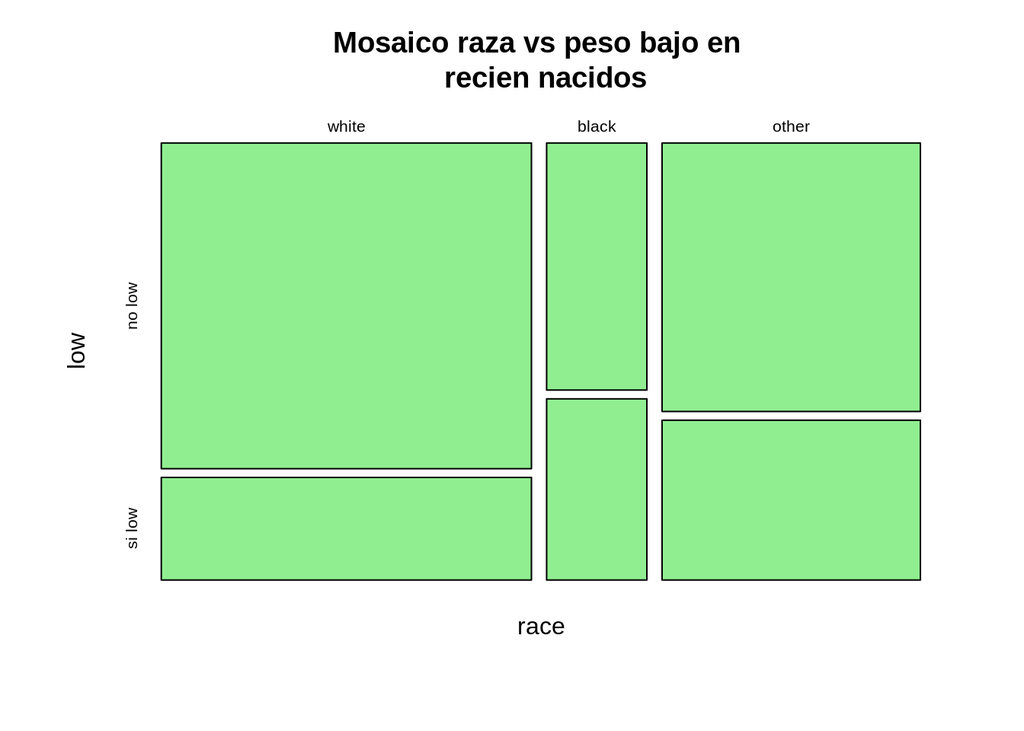

```r
plot(table(race,low), col="lightgreen", main= "Mosaico raza vs peso bajo en \n recien nacidos" )
```

## Dibuja un diagrama bidimensional de barras, con las barras organizadas en bloques, que permita visualizar la información de los ejercicios anteriores. Aprovecha para nombres adecuados a los bloques, colores a las barras, y añadir una leyenda que explique qué representa cada barra.

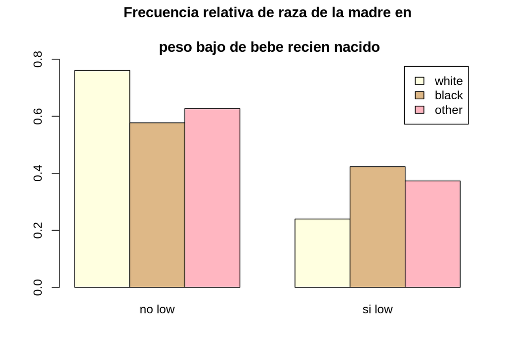

```r
barplot(prop.table(table(race,low), margin=1), beside =T, ylim = c(0,0.8),
        legend.text = T, col=c("lightyellow", "burlywood", "lightpink"),
        main = "Frecuencia relativa de raza de la madre en
        \n peso bajo de bebe recien nacido")
```

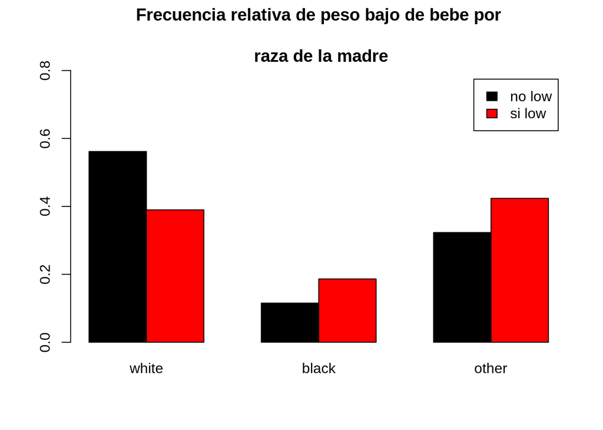

```r
barplot(t(prop.table(table(race,low), margin=2)), beside = T, ylim = c(0,0.8),
        legend.text = T, col=c("black", "red"),
        main = "Frecuencia relativa de peso bajo de bebe por
        \n raza de la madre")
```

## ¿Se puede obtener alguna conclusión de la tabla y el diagrama de barras anterior? Argumenta tu respuesta

## La frecuecia de bebes de bajo peso por raza de la madre es inferior del 45% donde el mayor porcentaje es el de las madres de raza negra, seguido por otras razas y el menor porcentaje es el de la raza blanca. ( 42.31%, 37.31%, 23.96%, respectivamente). Al comparar por frecuencia de bebes de bajo peso mas del 60 de los bebes de de bajo peso son de madres de raza negra y otras razas.

## Repite los cuatro ejercicios anteriores para los pares (madre fumadora o no, peso inferior a 2.5 kg o no) y para los pares (madre hipertensa o no, peso inferior a 2.5 kg o no.

## Madres Fumadoras vs Peso bajo del bebe

```r
smoke<-factor(bt$smoke, labels = c("no fumadora", "fumadora"))
low<-factor(bt$low, labels = c("no low", "si low"))
table(smoke,low)
```

```
##              low
## smoke         no low si low
##   no fumadora     86     29
##   fumadora        44     30
```

```r
round(prop.table(table(smoke,low), margin=1),3) # Frec Relativa Marginal de condicion de fumadora
```

```
##              low
## smoke         no low si low
##   no fumadora  0.748  0.252
##   fumadora     0.595  0.405
```

```r
round(prop.table(table(smoke,low), margin=2),3) # Frec Relativa Marginal de bajo peso del bebe
```

```
##              low
## smoke         no low si low
##   no fumadora  0.662  0.492
##   fumadora     0.338  0.508
```

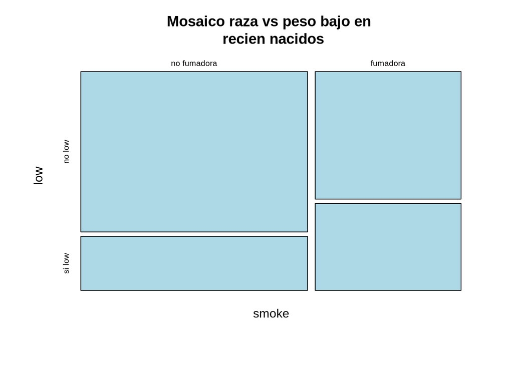

```r
plot(table(smoke,low), col="lightblue", main= "Mosaico raza vs peso bajo en \n recien nacidos" )
```

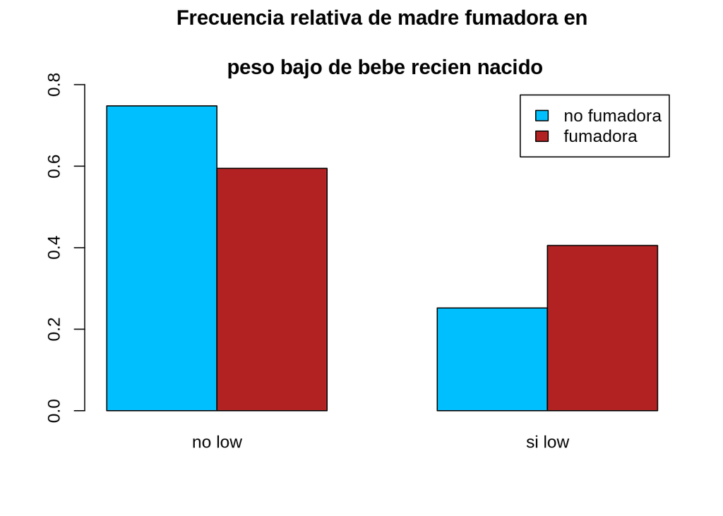

```r
barplot(prop.table(table(smoke,low), margin=1), beside = T, ylim = c(0,0.8),
        legend.text = T, col=c("deepskyblue", "firebrick"),
        main = "Frecuencia relativa de madre fumadora en
        \n peso bajo de bebe recien nacido")
```

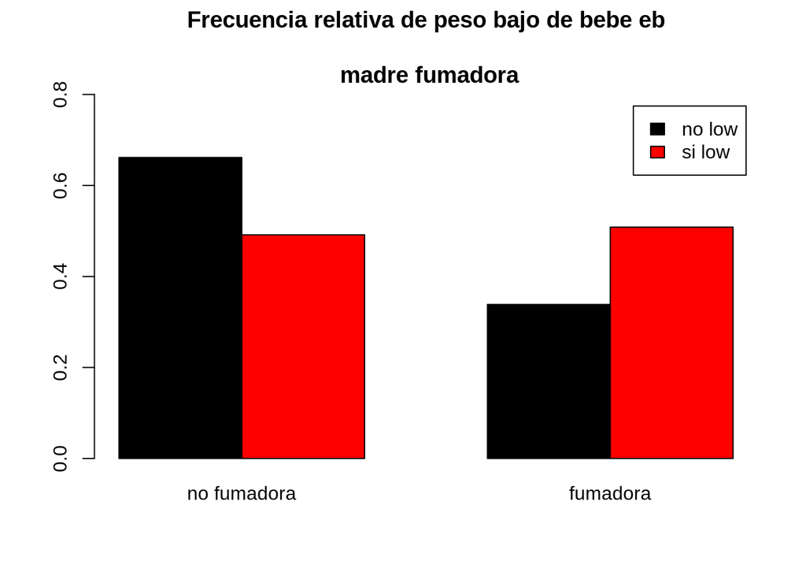

```r
barplot(t(prop.table(table(smoke,low), margin=2)), beside = T, ylim = c(0,0.8),
        legend.text = T, col=c("black", "red"),
        main = "Frecuencia relativa de peso bajo de bebe eb
        \n madre fumadora")
```

## Condicion de madre hipertensa vs bajo Peso del bebe

```r
ht<-factor(bt$ht, labels = c("no hipertensa", "hipertensa"))
low<-factor(bt$low, labels = c("no low", "si low"))
table(ht,low)
```

```
##                low
## ht              no low si low
##   no hipertensa    125     52
##   hipertensa         5      7
```

```r
round(prop.table(table(ht,low), margin=1),3)  # Frec Relativa Marginal de condicion de hipertension de la madre
```

```
##                low
## ht              no low si low
##   no hipertensa  0.706  0.294
##   hipertensa     0.417  0.583
```

```r
round(prop.table(table(ht,low), margin=2),3)  # Frec Relativa Marginal de condicion de bajo peso del bebe
```

```
##                low
## ht              no low si low
##   no hipertensa  0.962  0.881
##   hipertensa     0.038  0.119
```

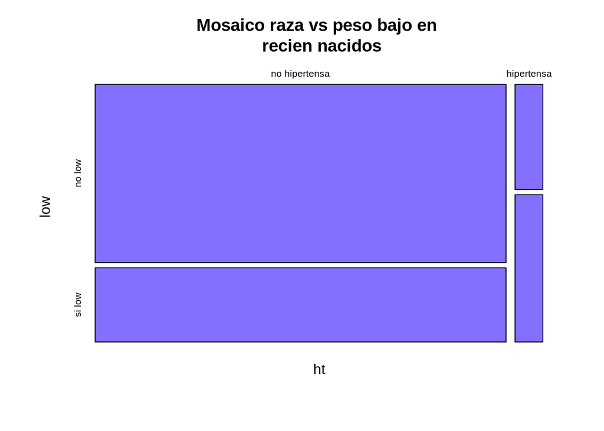

```r
plot(table(ht,low), col="lightslateblue", main= "Mosaico raza vs peso bajo en \n recien nacidos" )
```

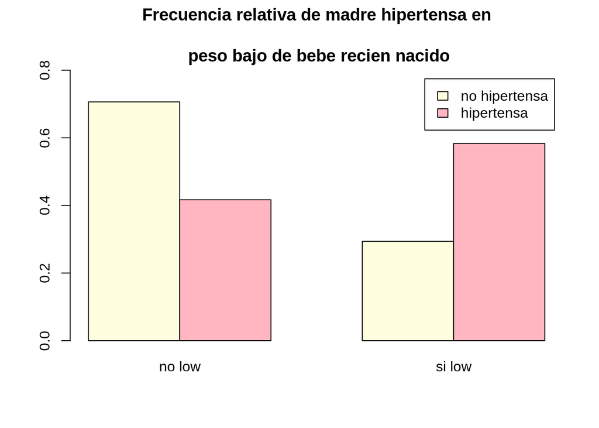

```r
barplot(prop.table(table(ht,low), margin=1), beside = T, ylim = c(0,0.8),
        legend.text = T, col=c("lightyellow", "lightpink"),
        main = "Frecuencia relativa de madre hipertensa en
        \n peso bajo de bebe recien nacido")
```

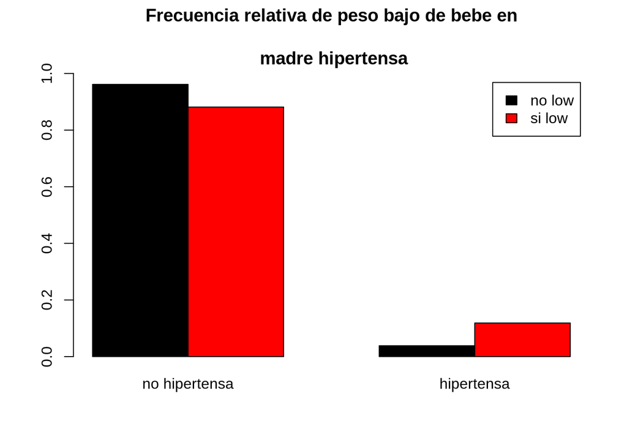

```r
barplot(t(prop.table(table(ht,low), margin=2)), beside = T, ylim = c(0,1),
        legend.text = T, col=c("black", "red"),
        main = "Frecuencia relativa de peso bajo de bebe en
        \n madre hipertensa")
```

## Calcula una tabla de frecuencias relativas marginales de las ternas (raza de la madre, madre fumadora o no, peso inferior a 2.5 kg o no) que permita ver si la raza de la madre y su condición de fumadora o no fumadora influyen en el peso del bebé.

```r
ftable(prop.table(table(race,smoke,low), margin = c(1,2)))
```

```
##                   low     no low     si low
## race  smoke
## white no fumadora     0.90909091 0.09090909
##       fumadora        0.63461538 0.36538462
## black no fumadora     0.68750000 0.31250000
##       fumadora        0.40000000 0.60000000
## other no fumadora     0.63636364 0.36363636
##       fumadora        0.58333333 0.41666667
```

## Dibuja un diagrama de mosaico de la tabla del ejercicio anterior.

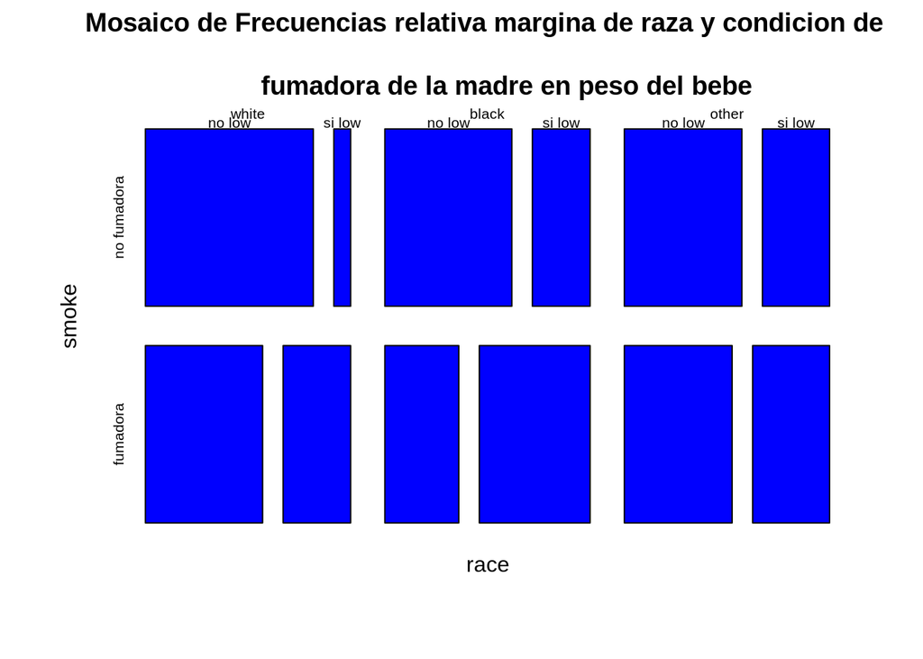

```r
plot(prop.table(table(race,smoke,low), margin = c(1,2)),
     main= "Mosaico de Frecuencias relativa margina de raza y condicion de \n
     fumadora de la madre en peso del bebe", col= "blue")
```